# All samples analysis

Valerio Reffo

2026-03-08

```r
library(SpatialExperiment)
library(anndataR)
library(ggspavis)
library(patchwork)
library(spatstat.geom)
library(spatstat)
library(sosta)
library(purrr)
library(readxl)
library(dplyr)
library(spatialFDA)
library(fda)
# survival analysis
library(survival)
library(survminer)
```

Path of the HoverNet data

```r
data_path <- "/mnt/ganimede/shared/imageFeatureTCGA_OV/hovernet/h5ad"
img_path <- "/mnt/ganimede/shared/imageFeatureTCGA_OV/hovernet/thumb"
```

# Micron per Pixel extraction

Extract from xlsx file the info about mpp conversion

```r
xlsx_path <- "/mnt/europa/valerio/repositories/spatialPointProcess_clustering/dataset/TCGA_data/image_metadata_TCGA.xlsx"

# 2. Read the excel file
metadata <- read_excel(xlsx_path)

# 2b. Correct row 2 because that slide is 40x, not 20x
metadata <- metadata |>
  mutate(
    `Image Name` = sub("\\.[a-zA-Z0-9]+$", "", `Image Name`),
    # Use grepl to match the start of the image name
    `Objective Power` = if_else(grepl("TCGA-13-A5FU", `Image Name`), "40", `Objective Power`),
    AppMag            = if_else(grepl("TCGA-13-A5FU", `Image Name`), "40", AppMag),
    MPP               = if_else(grepl("TCGA-13-A5FU", `Image Name`), "0.252", MPP),
    MPP_X             = if_else(grepl("TCGA-13-A5FU", `Image Name`), "0.252", MPP_X),
    MPP_Y             = if_else(grepl("TCGA-13-A5FU", `Image Name`), "0.252", MPP_Y)
  )

# # 3. Filter for your 6 samples and extract the Image Name and MPP columns
# # (Note: using backticks because the column name has a space)
# mpp_values <- metadata |>
#   dplyr::mutate(core_id = sub("\\.svs$", "", `Image Name`),
#     patientID = substr(`Image Name`, 1, 12)) |>
#   dplyr::select(`Image Name`, patientID, MPP, core_id) |>
#   dplyr::mutate(MPP = as.numeric(MPP))
#
# # 4. Convert it into a named vector so you can easily use it later
# # (e.g., mpp_vector["TCGA-42-2587...svs"] will return its specific MPP)
# mpp_vector <- setNames(mpp_values$MPP, mpp_values$`Image Name`)

# Print the result
# print(mpp_vector)
```

## Windows

HoverNet masks saving and reading

```r
# win_hovernet <- imap(spe_list, \(spe, name) {
#
#   base_dir <- "/mnt/ganimede/shared/imageFeatureTCGA_OV/hovernet/mask"
#   png_name <- paste0(sub("\\.[a-zA-Z0-9]+$", "", name), ".png")
#   img_file <- file.path(base_dir, png_name)
#
#   # Add a safety check so you get a clear error if the file is truly missing
#   if (!file.exists(img_file)) {
#     stop(paste("Cannot find image file:", img_file))
#   }
#
#   img <- imager::load.image(img_file)
#
#   return(img)
# })
#
# # saveRDS(win_hovernet, "/mnt/europa/valerio/repositories/spatialPointProcess_clustering/dataset/TCGA_data/window_masks_HoverNet_fullsamples.rds")
#
#
# win_hovernet <- readRDS("/mnt/europa/valerio/repositories/spatialPointProcess_clustering/dataset/TCGA_data/window_masks_HoverNet_fullsamples.rds")
```

## Metadata

```r
metadata <- readRDS("~/repositories/spatialPointProcess_clustering/dataset/TCGA_data/survival_dataset_&_metadata.rds")
```

Function to transform from anndata to spatialExperiment

```r
ann2spe <- \(data_path,
             spat_coords_name = c("x", "y"),
             img_path = NULL,
             mpp_value = NULL, ...) {
  ann <- anndataR::read_h5ad(data_path)
  #object to build SpatialExperiment
  counts <- t(ann$X) # transpose it
  cd <- ann$obs
  meta <- ann$uns
  spat <- ann$obsm$spatial
  colnames(spat) <- spat_coords_name
  cd <- cbind(cd, spat)
  spe <- SpatialExperiment::SpatialExperiment(assays = base::list("counts" = counts),
                                              colData = cd,
                                              metadata = meta,
                                              spatialCoordsNames = spat_coords_name,
                                              imageSources = img_path, ...)
  metadata(spe)$MPP <- mpp_value
  spe
}
```

Reading all the samples togheter

```r
# spe_list <- readRDS("~/repositories/spatialPointProcess_clustering/dataset/spe_list_107samples_TCGA-OV.rds")

# 2. Get a list of ALL files in that folder ending with .h5ad
# full.names = TRUE ensures we get the complete file path, not just the file name
# h5_files <- list.files(path = data_path, pattern = "\\.h5ad$", full.names = TRUE)
#
# # Optional: Set the names of the vector to the file names (without the path)
# # so your final list of SPE objects is neatly named!
# names(h5_files) <- sub("\\.h5ad$", "", basename(h5_files))
#
# # 3. Loop through all the files and apply your function
# spe_list <- imap(h5_files, function(current_h5_file, file_name) {
#
#   # Optional: If your images are in another folder, you can construct the img_path here
#   current_img_file <- file.path(img_path, paste0(file_name, ".png"))
#
#   # B. Look up the exact MPP value for this specific core_id
#   current_mpp <- unname(mpp_values$MPP[mpp_values$core_id == file_name])
#
#   # Optional check: If MPP is missing from the tibble, warn the user
#   if (is.na(current_mpp)) {
#     message("Warning: No MPP value found for ", file_name, ". Setting to NA.")
#   }
#
#   # 4. Use tryCatch to prevent the loop from crashing if one file is broken
#   tryCatch({
#
#     # Call your custom function!
#     # (If you don't have images/mpp values for this batch, leave them as NULL)
#     spe <- ann2spe(
#       data_path = current_h5_file,
#       img_path = current_img_file,      # Update this if you have images
#       mpp_value = current_mpp      # Update this if you have mpp values
#     )
#
#     return(spe)
#
#   }, error = function(e) {
#     # If a file fails to load, print an error message and return NULL
#     message("Failed to load: ", basename(current_h5_file))
#     message("Error: ", e$message)
#     return(NULL)
#   })
#
# }) |>
#   # 5. Drop any NULLs (files that failed to load)
#   compact()

#saveRDS(spe_list, "/mnt/europa/valerio/repositories/spatialPointProcess_clustering/dataset/spe_list_107samples_TCGA-OV.rds")
```

# Checking for bad samples

Sample spe_list

```r
# set.seed(123)
# thumbs_samples <- imap(spe_list, \(spe, name) {
#   subspe <- spe[, sample(ncol(spe), 10000)]
#   plot <- ggplot(spatialCoords(subspe), aes(x = x, y = y)) +
#     # 2. Plot the valid cells (Extracts coordinates on the fly)
#     geom_point(color = "blue", size = 0.1, alpha = 0.5) +
#     # Force standard Cartesian proportions so the image isn't squished
#     coord_fixed() +
#     theme_minimal() +
#     labs(
#       title = name)
#   plot
# })
# thumbs_samples
```

Images with apparently more copy of the same tissue

```r
double_ids <- c(
  "TCGA-13-A5FT",
  "TCGA-25-1631",
  "TCGA-25-1632",
  "TCGA-25-1633",
  "TCGA-25-1877",
  "TCGA-42-2582",
  "TCGA-42-2588",
  "TCGA-42-2589",
  "TCGA-42-2590",
  "TCGA-42-2591",
  "TCGA-42-2593",
  "TCGA-59-A5PD",
  "TCGA-OY-A56P",
  "TCGA-OY-A56Q",
  "TCGA-VG-A8LO",
  "TCGA-VG-A8LO"   # doppio perché appare 2 volte 01-DX1 e 02-DX2
)

#saveRDS(double_ids, file = "/mnt/europa/valerio/repositories/spatialPointProcess_clustering/dataset/bad_samples_fromthe107.rds")
```

Remove bad samples from the spe_list Add the sample_id with the short name of the sample to identify the patient and then filter the samples in which I have similar slice of tissue and I can’t understand if they are replicate or adiacent samples, and in which direction is the adiacence.

```r
# spe_list <- imap(spe_list, \(spe, name) {
#   spe$sample_id <- NULL
#   spe$sample_id <- substr(name, 1, 12)
#   spe
# })
# spe_list <- spe_list[!substr(names(spe_list), 1, 12) %in% double_ids]
```

16 samples removed

Dimension of spe_list

```r
# format(object.size(spe_list), units = "MB")
```

Resave the thing and divide it in 2 half

```r
#saveRDS(spe_list, file = "/mnt/europa/valerio/repositories/spatialPointProcess_clustering/dataset/spe_list_91_good_samples.rds")

# spe_list <- readRDS("/mnt/europa/valerio/repositories/spatialPointProcess_clustering/dataset/spe_list_91_good_samples.rds")
```

```r
# length(spe_list)
# (1:91)[1:floor(length(spe_list)/2)]
# (1:91)[-(1:floor(length(spe_list)/2))]

# # first 45 samples
# spe_list[1:floor(length(spe_list)/2)] |>
#   saveRDS("/mnt/europa/valerio/repositories/spatialPointProcess_clustering/dataset/spe_list_first_45_good_samples.rds")
#
# # second 46 samples
# spe_list[-(1:floor(length(spe_list)/2))] |>
#   saveRDS("/mnt/europa/valerio/repositories/spatialPointProcess_clustering/dataset/spe_list_second_46_good_samples.rds")
```

# ppp objects creation

```r
save_ppp_individually <- function(spe_list, mask_hovernet, metadata,
                                  out_dir = "/mnt/europa/valerio/repositories/spatialPointProcess_clustering/dataset/samples_ppp") {

  # 1. Ensure the output directory exists
  if (!dir.exists(out_dir)) {
    dir.create(out_dir, recursive = TRUE, showWarnings = FALSE)
    message(paste("Created directory:", out_dir))
  }

  # 2. Iterate over each sample
  for (sample_name in names(spe_list)) {
    message(paste("Processing:", sample_name))

    spe  <- spe_list[[sample_name]]
    mask <- mask_hovernet[[sample_name]]

    # Safety check
    if (is.null(mask)) {
      warning(paste("No mask found for", sample_name, "- skipping."))
      next
    }

    # 3. Extract metadata for the current sample
    meta_row <- metadata |>
      dplyr::filter(`Image Name` == sample_name) |>
      dplyr::select(AppMag, MPP)

    # Safely default to 40 and 1 if metadata is missing or NA
    if (nrow(meta_row) == 0) {
      app_mag <- 40
      mpp     <- 1
    } else {
      app_mag <- tidyr::replace_na(as.numeric(meta_row$AppMag[1]), 40)
      mpp     <- tidyr::replace_na(as.numeric(meta_row$MPP[1]), 1)
    }

    # A. Extract logical matrix and transpose to [y, x]
    mask_mat <- mask[,,1,1] > 0.5
    mask_spatstat <- t(mask_mat)

    # B. Create the thumbnail window
    # Note: If width()/height() are custom functions, ensure they are loaded.
    # Otherwise, you can use dim(mask)[1] and dim(mask)[2]
    win_thumb <- owin(
      xrange = c(0, dim(mask)[1]),
      yrange = c(0, dim(mask)[2]),
      mask = mask_spatstat
    )

    # C. Calculate exact scale
    exact_scale <- app_mag / 1.25

    # D. Stretch the window
    win_final <- affine(win_thumb, mat = diag(c(exact_scale, exact_scale)))

    # E. Build the PPP object
    coords <- spatialCoords(spe)
    my_ppp <- ppp(
      x = coords[, "x"],
      y = coords[, "y"],
      window = win_final,
      marks = as.factor(spe$type)
    )

    # F. Rescale
    if (mpp == 1) {
      warning(paste("No MPP found for", sample_name, "- leaving in pixels"))
    }

    ppp_microns <- rescale(my_ppp, s = 1/mpp, unitname = c("micron", "microns"))

    # 4. Save the individual object to the specified directory
    file_path <- file.path(out_dir, paste0(sample_name, ".rds"))
    saveRDS(ppp_microns, file = file_path)

    message(paste("Saved successfully:", file_path))
  }

  message("All samples processed.")
}

# # Run the function:
# save_ppp_individually(spe_list, win_hovernet, metadata)
```

Iterative reading and acting with ppp samples

```r
# sample_names <- names(spe_list)
# saveRDS(sample_names, file = "/mnt/europa/valerio/repositories/spatialPointProcess_clustering/dataset/samples_name.rds")
```

```r
# path_dir = "/mnt/europa/valerio/repositories/spatialPointProcess_clustering/dataset/samples_ppp"
# map(sample_names, \(sample_name){
#     file_path <- file.path(path_dir, paste0(sample_name, ".rds"))
#     ppp_sample <- readRDS(file_path)
#
#     # 1. Save the original marks vector
#     original_marks <- marks(ppp_sample)
#
#     # 2. Create the new merged vector
#     target_levels <- c("benign epithelial", "stromal")
#
#     if (any(target_levels %in% levels(original_marks))) {
#       merged_marks <- forcats::fct_collapse(original_marks,
#                                    "stromal_benign" = target_levels)
#     } else {
#       merged_marks <- original_marks # Fallback if neither exist
#     }
#
#     # 3. Assign BOTH vectors to the ppp object as a data frame
#     marks(ppp_sample) <- data.frame(
#       original_type = original_marks,
#       merged_type   = merged_marks
#     )
#     saveRDS(ppp_sample, file_path)
# })
```

# Read the ppp objects

```r
sample_names <- readRDS(file = "/mnt/europa/valerio/repositories/spatialPointProcess_clustering/dataset/samples_name.rds")
path_dir = "/mnt/europa/valerio/repositories/spatialPointProcess_clustering/dataset/samples_ppp"
ppp_list <- purrr::map(sample_names, \(sample_name){
    file_path <- file.path(path_dir, paste0(sample_name, ".rds"))
    ppp_sample <- readRDS(file_path)
    ppp_sample
})
names(ppp_list) <- sample_names
head(ppp_list)
```

```
## $`TCGA-13-A5FU-01Z-00-DX1.9AD9E4B9-3F87-4879-BC0F-148B12C09036`
## Marked planar point pattern: 1409484 points
## Mark variables: original_type, merged_type
## window: binary image mask
## 2685 x 3246 pixel array (ny, nx)
## enclosing rectangle: [0, 26175.744] x [0, 21651.84] microns
##
## $`TCGA-23-1021-01Z-00-DX1.F07C221B-D401-47A5-9519-10DE59CA1E9D`
## Marked planar point pattern: 1493877 points
## Mark variables: original_type, merged_type
## window: binary image mask
## 2024 x 3237 pixel array (ny, nx)
## enclosing rectangle: [0, 26175.677] x [0, 16366.874] microns
##
## $`TCGA-23-1022-01Z-00-DX1.AF9E523E-CB0F-4AB5-AD43-C96731BF9141`
## Marked planar point pattern: 1280056 points
## Mark variables: original_type, merged_type
## window: binary image mask
## 2595 x 2988 pixel array (ny, nx)
## enclosing rectangle: [0, 24162.163] x [0, 20984.208] microns
##
## $`TCGA-23-1023-01Z-00-DX1.0C96E118-A4D9-4A9A-B95E-C0AA114D2483`
## Marked planar point pattern: 1596703 points
## Mark variables: original_type, merged_type
## window: binary image mask
## 2078 x 3735 pixel array (ny, nx)
## enclosing rectangle: [0, 30202.704] x [0, 16803.539] microns
##
## $`TCGA-23-1024-01Z-00-DX1.B9194D3F-C6F4-4FC8-B0CA-6E347FF4F885`
## Marked planar point pattern: 2025323 points
## Mark variables: original_type, merged_type
## window: binary image mask
## 2738 x 3424 pixel array (ny, nx)
## enclosing rectangle: [0, 27687.834] x [0, 22140.563] microns
##
## $`TCGA-23-1026-01Z-00-DX1.2875B4F7-D6B2-4C72-8A68-4E7C92D04BF0`
## Marked planar point pattern: 1256364 points
## Mark variables: original_type, merged_type
## window: binary image mask
## 2728 x 3486 pixel array (ny, nx)
## enclosing rectangle: [0, 28189.19] x [0, 22059.699] microns
```

# Second order statistic analysis

npoints for each cell type and potential RAM cost

# memory check

Check if Lcross will crash - all unsupervised copilot code

Check memory usage based on rmax - all unsupervised copilot code

# Homogeneus ppp

## Lfunction estimate

L function between neoplastic and stromal

```r
# Lcross_homo <- map(ppp_list, \(ppp_obj) {
#      # Calculate Lcross
#      L <- Lcross(ppp_obj, i = "neoplastic", j = "stromal", correction = "border", rmax = 50)
#      L
# })
```

Downsample to avoid crash

Function to estimate Lcross function for homogeneus point pattern between 2 marks and with downsample

```r
Lcross_personal <- function(ppp_obj, mark_i, mark_j, mark_column, downsample = TRUE, n_down = 10000, ...) {

  # 0. If marks are a dataframe, extract the specific column we want to use!
  if (is.data.frame(marks(ppp_obj))) {
    marks(ppp_obj) <- marks(ppp_obj)[[mark_column]]
  }
  # 1. Get the indices of the specific cell types dynamically
  idx_i <- which(marks(ppp_obj) == mark_i)
  idx_j <- which(marks(ppp_obj) == mark_j)

  # Safety check: ensure both cell types actually exist in the image!
  if(length(idx_i) < 2 | length(idx_j) < 2) {
    warning(paste("Not enough points for", mark_i, "and/or", mark_j, "to compute Lcross. Returning NULL."))
    return(NULL)
  }

  # 2. Handle Downsampling
  if (downsample) {
    # Randomly sample a maximum of n_down cells of each type
    keep_i <- sample(idx_i, min(length(idx_i), n_down))
    keep_j <- sample(idx_j, min(length(idx_j), n_down))

    # Subset the ppp object
    ppp_sub <- ppp_obj[c(keep_i, keep_j)]

  } else {
    # Even if we don't downsample, subsetting to JUST the two marks of interest
    # saves a massive amount of memory for spatstat calculation
    ppp_sub <- ppp_obj[c(idx_i, idx_j)]
  }

  # 3. Calculate Lcross dynamically using the provided mark names
  L <- Lcross(ppp_sub,
              i = mark_i,
              j = mark_j, ...)

  return(L)
}
```

We investigate about the relationship between neoplastic nuclei and stromal/benign epitelium nuclei

```r
r_values <- seq(0, 100, length.out = 200)

Lcross_stroben <- map(ppp_list, \(ppp_obj) {
  Lcross_personal(ppp_obj,
                  mark_i = "neoplastic",
                  mark_j = "stromal_benign",
                  mark_column = "merged_type",
                  downsample = TRUE, n_down = 40000, rmax = 100,
                  correction = "border", r = r_values)
})

#saveRDS(Lcross_stroben, file = "/mnt/europa/valerio/repositories/spatialPointProcess_clustering/dataset/Lcross_stromal_benignEpitelial_91_samples.rds")
```

Let’s check for NA in the result

```r
na_summary_per_sample <- imap_dfr(Lcross_stroben, \(fv_obj, sample_name) {

  # Handle cases where the Lcross calculation returned NULL
  if (is.null(fv_obj)) {
    return(tibble(
      sample = sample_name,
      r_na = NA_integer_,
      theo_na = NA_integer_,
      border_na = NA_integer_,
      status = "Skipped (NULL)"
    ))
  }

  # Convert the fv object to a standard dataframe
  df <- as.data.frame(fv_obj)

  # Count NAs for each specific column
  tibble(
    sample = sample_name,
    r_na = sum(is.na(df$r)),
    theo_na = sum(is.na(df$theo)),
    border_na = sum(is.na(df$border)),
    status = "Computed"
  )
})

# View the per-sample breakdown
print(na_summary_per_sample)
```

```
## # A tibble: 91 × 5
##    sample                                          r_na theo_na border_na status
##    <chr>                                          <int>   <int>     <int> <chr>
##  1 TCGA-13-A5FU-01Z-00-DX1.9AD9E4B9-3F87-4879-BC…     0       0         0 Compu…
##  2 TCGA-23-1021-01Z-00-DX1.F07C221B-D401-47A5-95…     0       0         0 Compu…
##  3 TCGA-23-1022-01Z-00-DX1.AF9E523E-CB0F-4AB5-AD…     0       0         0 Compu…
##  4 TCGA-23-1023-01Z-00-DX1.0C96E118-A4D9-4A9A-B9…     0       0         0 Compu…
##  5 TCGA-23-1024-01Z-00-DX1.B9194D3F-C6F4-4FC8-B0…     0       0         0 Compu…
##  6 TCGA-23-1026-01Z-00-DX1.2875B4F7-D6B2-4C72-8A…     0       0         0 Compu…
##  7 TCGA-23-1027-01Z-00-DX1.53F9DFF4-6811-4184-B2…     0       0         0 Compu…
##  8 TCGA-23-1028-01Z-00-DX1.117B4B7B-F796-4D33-A6…     0       0         0 Compu…
##  9 TCGA-23-1029-01Z-00-DX1.0044B39A-51B3-4F76-90…     0       0         0 Compu…
## 10 TCGA-23-1030-01Z-00-DX1.FC93147F-FB55-4C62-B1…     0       0         0 Compu…
## # ℹ 81 more rows
```

```r
# 2. Count NAs for EVERYTHING (Grand Totals)
grand_totals <- na_summary_per_sample |>
  summarise(
    total_r_NAs = sum(r_na, na.rm = TRUE),
    total_theo_NAs = sum(theo_na, na.rm = TRUE),
    total_border_NAs = sum(border_na, na.rm = TRUE),
    total_failed_samples = sum(status == "Skipped (NULL)")
  )

# View the total counts
print(grand_totals)
```

```
## # A tibble: 1 × 4
##   total_r_NAs total_theo_NAs total_border_NAs total_failed_samples
##         <int>          <int>            <int>                <int>
## 1           0              0                0                    0
```

There should be some NA for overflow, but there is no one… ok i guess

Plot the results

```r
plot_fv_list <- function(list_of_funcs, comparison_df, correction = "border") {

  # 1. Run the map_dfr block dynamically on whatever list you provide
  df_lcross <- map_dfr(names(list_of_funcs), function(slide_name) {

    # Extract the specific L-function object from the provided list
    L_obj <- list_of_funcs[[slide_name]]

    as.data.frame(L_obj) |>
      mutate(
        Slide = slide_name,
        # Use .data[[correction]] to dynamically grab the 'border' column (or 'iso', etc.)
        L_r_minus_r = .data[[correction]] - r,

        # Extract the marks names exactly as you designed
        mark_i = trimws(strsplit(gsub("list\\(|\\)", "", attr(L_obj, "fname")[2]), ",")[[1]][1]),
        mark_j = trimws(strsplit(gsub("list\\(|\\)", "", attr(L_obj, "fname")[2]), ",")[[1]][2])
      )
  })

  # 2. Join the metadata (comparison_benign) into the dataframe
  df_lcross <- df_lcross |>
    mutate(
      # Extract the first 12 characters to match "TCGA-XX-XXXX"
      patientID = substr(Slide, 1, 12)
    ) |>
    # Merge the cluster info based on the patientID
    left_join(comparison_df, by = "patientID") |>
    # Convert cluster_ilaria to a factor so ggplot uses discrete colors instead of a continuous gradient
    mutate(cluster_ilaria = as.factor(cluster))

  # 3. Build the ggplot
  # Note: group = Slide ensures each patient gets their own line
  #       color = cluster_ilaria applies the cluster colors
  p <- ggplot(df_lcross, aes(x = r, y = L_r_minus_r, group = Slide, color = cluster_ilaria)) +
    geom_hline(yintercept = 0, linetype = "dashed", color = "gray50") +
    geom_line(alpha = 0.7, linewidth = 0.6) +
    theme_minimal() +
    labs(
      title = paste0("L-cross Function: ", df_lcross$mark_i[1], " vs ", df_lcross$mark_j[1]),
      subtitle = "Centered L-function (L(r) - r). Positive = Attraction, Negative = Repulsion",
      x = "Radius (r)",
      y = "L(r) - r",
      color = "Cluster" # Renamed legend title
    ) +
    theme(legend.position = "right")

  return(p)
}
```

load the comparison_df

```r
meta_ilaria <- readRDS("~/repositories/spatialPointProcess_clustering/dataset/TCGA_data/survival_dataset_&_metadata.rds")
```

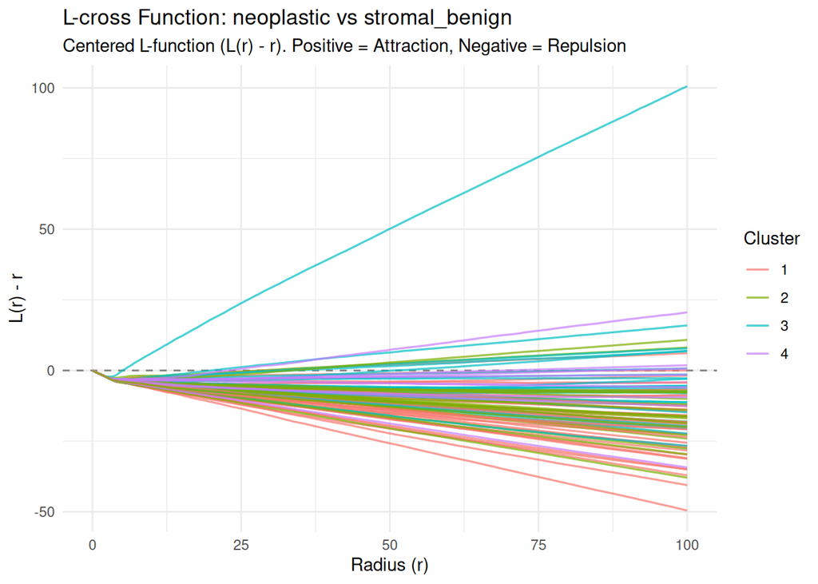

```r
plot_colored <- plot_fv_list(
  list_of_funcs = Lcross_stroben,
  comparison_df = meta_ilaria,
  correction = "border"
)

plot_colored
```

# generic function for smoothing funs

```r
fsmooth <- function(fcross_list, fun, M = 6, genLfun.fd = 4, centrata = F, ...)
{

  # 1. Calculate raw L-functions (Common for both)
  r <- fcross_list[[1]]$r
  mat_fun <- sapply(fcross_list, function(x) x$border)

  # 2. Apply centering ONLY if requested
  if(centrata == TRUE){
    mat_fun <- sweep(mat_fun, MARGIN = 1, STATS = r, FUN = "-")
  }

  # 3. Create Basis and Smooth
  K <- length(r) + M - 2
  genbasis <- create.bspline.basis(range(r), K, M, r)
  genfdPar <- fdPar(genbasis, genLfun.fd, lambda = 1e-11)

  genfdSmooth <- smooth.basis(r, mat_fun, genfdPar)
  Genfun.fd <- genfdSmooth$fd

  # 4. Set Names
  fdn_dist <- paste("Distanza (da 0 a", max(r), "micron)")
  fdnames <- list(fdn_dist,
                  "Gene" = colnames(mat_fun), # Crucial: use names of surviving columns
                  "Funzione")
  Genfun.fd$fdnames <- fdnames

  return(list(fd = Genfun.fd, fdPar = genfdPar,
              basis = genbasis, mat = mat_fun, r = r))
}
```

```r
Lfun_stroben <- fsmooth(Lcross_stroben, centrata = T)
```

```r
plot(Lfun_stroben$fd)
```

```
## [1] "done"
```

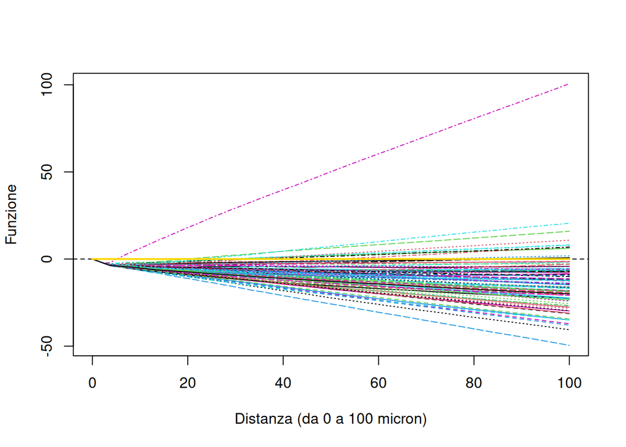

```r
lines(c(0,100), c(0,0), col = "gold", lwd = 2)
```

### Functional PCA

Calcoliamo fpca per 4 componenti e mostriamo il risultato sulla rotazione VARIMAX

```r
fpca <- pca.fd(Lfun_stroben$fd, nharm = 4, Lfun_stroben$fdPar)
rownames(fpca$scores) <- names(Lcross_stroben) # "nome" dei pazienti (numero del paziente)

fpcaVarmx <- varmx.pca.fd(fpca)
```

## Clustering

```r
set.seed(123)
fpca_km <- kmeans(fpca$scores[,c(1,4)], 4)
fpca_hc <- hclust(dist(fpca$scores[,c(1,4)]), method = "ward.D2")
memb <- cutree(fpca_hc, k = 4)
```

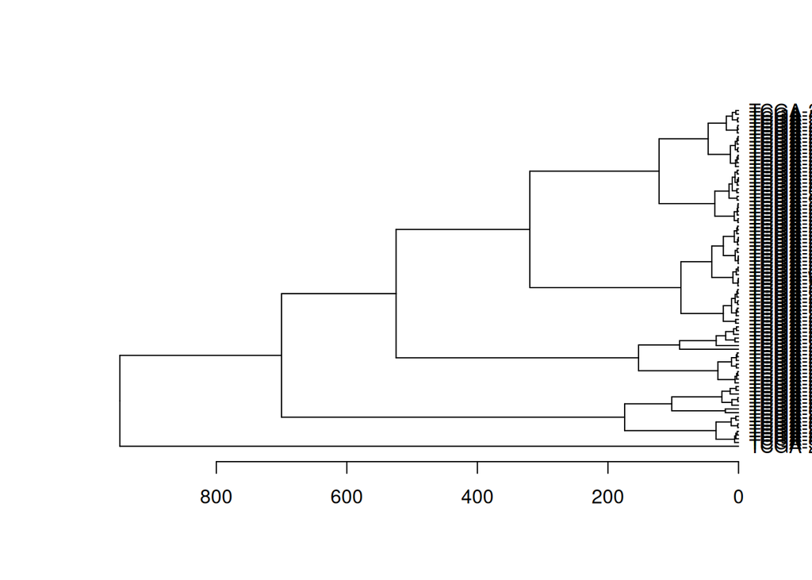

```r
dhc <- as.dendrogram(fpca_hc)
plot(dhc, cex = 0.1, horiz = T)
```

```r
#ggdendrogram(dhc, rotate = TRUE, size = 2)
table(kmean = fpca_km$cluster)
```

```
## kmean
##  1  2  3  4
## 18 20 52  1
```

```r
table(ward.d2 = memb)
```

```
## ward.d2
##  1  2  3  4
## 58 16 16  1
```

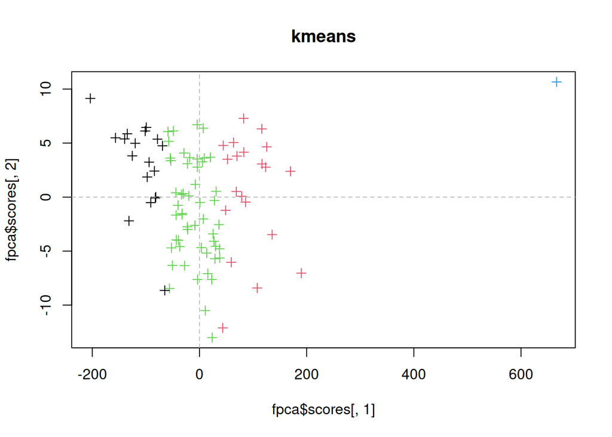

```r
plot(fpca$scores[,1], fpca$scores[,2], col = fpca_km$cluster, pch = 3, main = "kmeans")
abline(v = 0, lty = "dashed", col = "grey")
abline(h = 0, lty = "dashed", col = "grey")
```

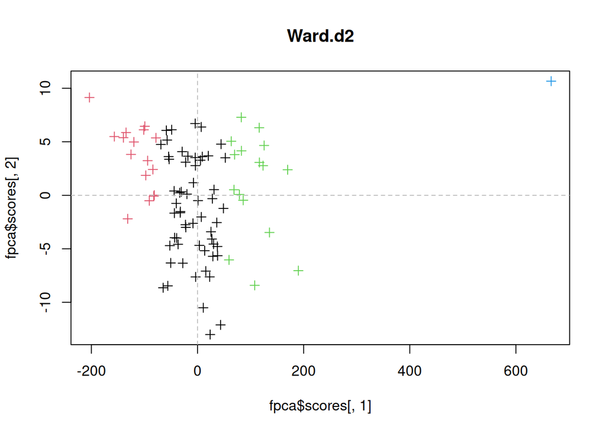

```r
plot(fpca$scores[,1], fpca$scores[,2], col = memb, pch = 3, main = "Ward.d2")
abline(v = 0, lty = "dashed", col = "grey")
abline(h = 0, lty = "dashed", col = "grey")
```

## Check the outlier

```r
poinside_plot <- \(ppp, title_p = "Spatial point pattern"){
  ggplot() +
    # 1. Plot the tissue mask (Extracts pixels on the fly)
    geom_raster(data = as.data.frame(Window(ppp)),
                aes(x = x, y = y), fill = "grey80") +

    # 2. Plot the valid cells (Extracts coordinates on the fly)
    geom_point(data = as.data.frame(ppp),
               aes(x = x, y = y, color = merged_type), size = 0.05, alpha = 0.5) +

    # Force standard Cartesian proportions so the image isn't squished
    coord_fixed() +
    theme_minimal() +
    labs(
      title = title_p,
      subtitle = "Colored by cell type with merged types",
      x = "X Coordinate",
      y = "Y Coordinate"
    )
}
```

Compare it with the patientID ppp with the lowest PC1 and the PC1 nearest to zero

```r
which.max(fpca$scores[,1]) # TCGA-23-1121-01Z-00-DX1.E2F25441-32C3-46BF-A845-CB4FA787E8CB OUTLIER
```

```
## TCGA-23-1121-01Z-00-DX1.E2F25441-32C3-46BF-A845-CB4FA787E8CB
##                                                           24
```

```r
which.min(fpca$scores[,1]) # TCGA-23-1030-01Z-00-DX1.FC93147F-FB55-4C62-B187-337A5C107096
```

```
## TCGA-23-1030-01Z-00-DX1.FC93147F-FB55-4C62-B187-337A5C107096
##                                                           10
```

```r
which((fpca$score[,1] > -5) & (fpca$score[,1] < 5)) # TCGA-57-1582-01Z-00-DX1.BDF02DAA-E520-46BD-A479-58CAA4354B1A the 83rd row
```

```
## TCGA-23-1120-01Z-00-DX1.59367B12-17F1-41AA-A6FB-8D940365176A
##                                                           23
## TCGA-25-1319-01Z-00-DX1.71EFB946-ACAF-4BA6-8855-D336268D87F0
##                                                           46
## TCGA-25-1328-01Z-00-DX1.A0145C96-19A9-4F2D-8570-ECF039F99405
##                                                           54
## TCGA-25-1627-01Z-00-DX1.7596F7F5-D705-46B4-B3A6-833D31482D28
##                                                           59
## TCGA-25-2400-01Z-00-DX1.AAD20514-6FF7-47A5-89DB-8AA15DCC101B
##                                                           76
## TCGA-57-1582-01Z-00-DX1.BDF02DAA-E520-46BD-A479-58CAA4354B1A
##                                                           83
```

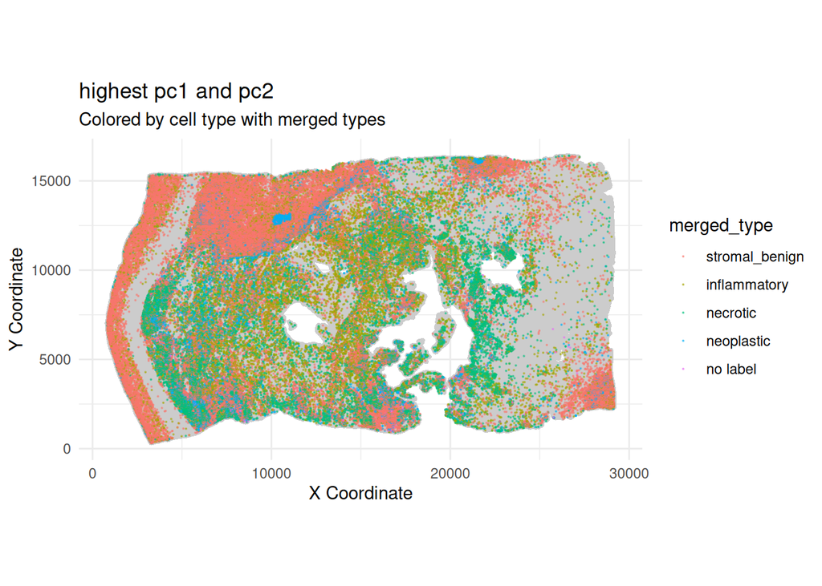

```r
poinside_plot(ppp_list[[24]], title_p = "highest pc1 and pc2")
```

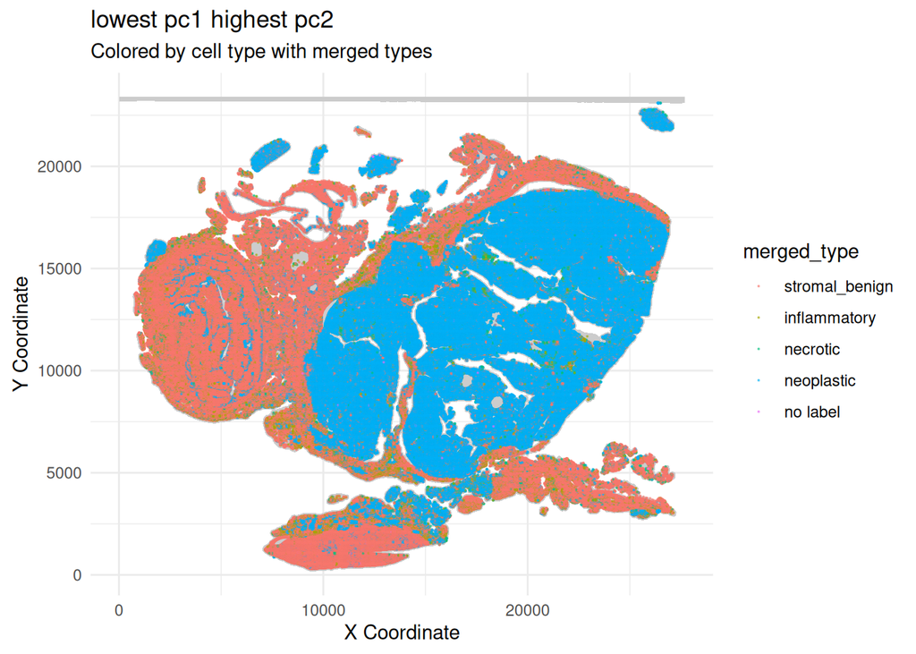

```r
poinside_plot(ppp_list[[which.min(fpca$scores[,1])]], title_p = "lowest pc1 highest pc2")
```

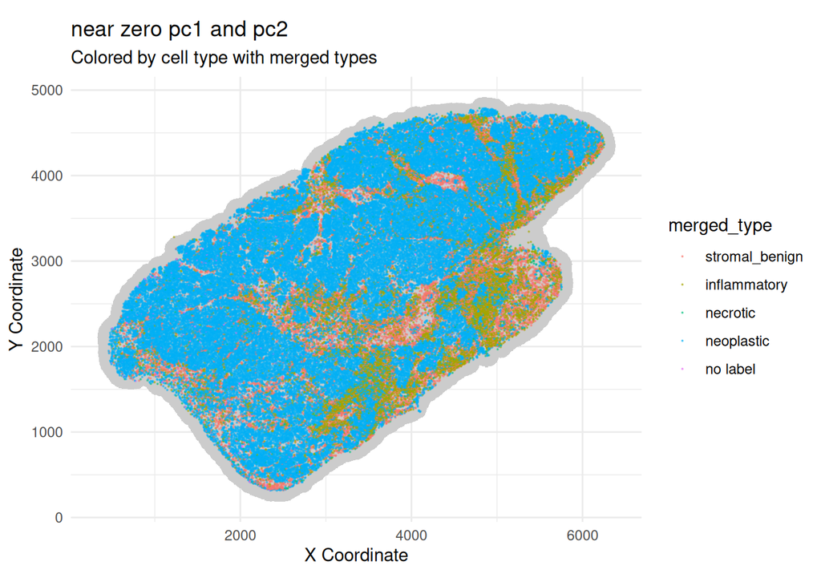

```r
poinside_plot(ppp_list[[83]], title_p = "near zero pc1 and pc2")
```

let’s remove the sample 24 and redo the analysis

```r
df_ilaria <- meta_ilaria |>
  dplyr::select(patientID, cluster)
# 3. Clean Dataset B to match IDs
# We extract the first 12 characters (e.g., "TCGA-25-1326")
df_clust <- data.frame(
  patientID = substr(names(memb), 1, 12),
  cluster_kmean = fpca_km$cluster,
  cluster_ward = memb
) |> print()
```

```
##                                                                 patientID
## TCGA-13-A5FU-01Z-00-DX1.9AD9E4B9-3F87-4879-BC0F-148B12C09036 TCGA-13-A5FU
## TCGA-23-1021-01Z-00-DX1.F07C221B-D401-47A5-9519-10DE59CA1E9D TCGA-23-1021
## TCGA-23-1022-01Z-00-DX1.AF9E523E-CB0F-4AB5-AD43-C96731BF9141 TCGA-23-1022
## TCGA-23-1023-01Z-00-DX1.0C96E118-A4D9-4A9A-B95E-C0AA114D2483 TCGA-23-1023
## TCGA-23-1024-01Z-00-DX1.B9194D3F-C6F4-4FC8-B0CA-6E347FF4F885 TCGA-23-1024
## TCGA-23-1026-01Z-00-DX1.2875B4F7-D6B2-4C72-8A68-4E7C92D04BF0 TCGA-23-1026
## TCGA-23-1027-01Z-00-DX1.53F9DFF4-6811-4184-B2FD-1F6706B948FD TCGA-23-1027
## TCGA-23-1028-01Z-00-DX1.117B4B7B-F796-4D33-A645-CD80E5C43E6D TCGA-23-1028
## TCGA-23-1029-01Z-00-DX1.0044B39A-51B3-4F76-90A9-00CDF851DE2A TCGA-23-1029
## TCGA-23-1030-01Z-00-DX1.FC93147F-FB55-4C62-B187-337A5C107096 TCGA-23-1030
## TCGA-23-1031-01Z-00-DX1.12B1996D-E5BB-424C-B59E-4BE7E1ED6BA1 TCGA-23-1031
## TCGA-23-1032-01Z-00-DX1.0C1074AE-D59C-4C74-B929-593AE89E5DC1 TCGA-23-1032
## TCGA-23-1107-01Z-00-DX1.5B9C1283-62B5-4329-873D-009FA939CA69 TCGA-23-1107
## TCGA-23-1109-01Z-00-DX1.FB0886B9-8108-4A74-8A29-FEA4381AD69C TCGA-23-1109
## TCGA-23-1110-01Z-00-DX1.61C2DBB8-7F5C-4878-BEDC-6AE061A2D7D4 TCGA-23-1110
## TCGA-23-1111-01Z-00-DX1.A99421E1-C73E-42AE-990F-E5E6D26EDDBE TCGA-23-1111
## TCGA-23-1113-01Z-00-DX1.D72B1587-444A-4DEC-8D92-703699822BE2 TCGA-23-1113
## TCGA-23-1114-01Z-00-DX1.26CCA42E-4947-4318-A983-D3B31603482E TCGA-23-1114
## TCGA-23-1116-01Z-00-DX1.FC5FC1E1-56DD-498C-AA9F-4434C6E733A8 TCGA-23-1116
## TCGA-23-1117-01Z-00-DX1.783914B6-B079-4828-B77B-4C6306FAE4C1 TCGA-23-1117
## TCGA-23-1118-01Z-00-DX1.D69E130E-33C7-4F8A-99AF-400B81378578 TCGA-23-1118
## TCGA-23-1119-01Z-00-DX1.44D3D70A-A421-4962-8385-2A3CF8E9880A TCGA-23-1119
## TCGA-23-1120-01Z-00-DX1.59367B12-17F1-41AA-A6FB-8D940365176A TCGA-23-1120
## TCGA-23-1121-01Z-00-DX1.E2F25441-32C3-46BF-A845-CB4FA787E8CB TCGA-23-1121
## TCGA-23-1122-01Z-00-DX1.991C230C-E3B4-4DAC-9DCC-69E9FA7DF772 TCGA-23-1122
## TCGA-23-1123-01Z-00-DX1.764A8E5C-F2E7-441D-B9FB-23ECF7183740 TCGA-23-1123
## TCGA-23-1809-01Z-00-DX1.A8767DEC-EB1A-4EDC-906E-C0560A30455F TCGA-23-1809
## TCGA-23-2072-01Z-00-DX1.478243FF-BFF0-48A4-ADEA-DE789331A50E TCGA-23-2072
## TCGA-23-2077-01Z-00-DX1.9EB664FA-CC13-4A49-89BA-8A4573CE48F1 TCGA-23-2077
## TCGA-23-2078-01Z-00-DX1.E31A9C1E-00EF-4B0D-A15D-6A5C2D00E986 TCGA-23-2078
## TCGA-23-2079-01Z-00-DX1.01383205-B7A7-4529-9207-880687650A50 TCGA-23-2079
## TCGA-23-2081-01Z-00-DX1.4105A382-4C2B-4C62-AC93-CB21CC360254 TCGA-23-2081
## TCGA-23-2084-01Z-00-DX1.94780F2B-9A88-47ED-982B-0048081309C9 TCGA-23-2084
## TCGA-23-2641-01Z-00-DX1.DB792236-39EC-4090-9938-B0915C3378A0 TCGA-23-2641
## TCGA-23-2643-01Z-00-DX1.E60DF03D-326E-4182-84DA-77263C4C52B3 TCGA-23-2643
## TCGA-23-2645-01Z-00-DX1.72C0AB89-9A64-4656-B03E-A5D65BA03188 TCGA-23-2645
## TCGA-23-2647-01Z-00-DX1.21E5D0D8-6BA8-4D49-BA70-EC228CF10387 TCGA-23-2647
## TCGA-23-2649-01Z-00-DX1.C94C3B32-D5F5-4A85-9F35-50B377FF9E75 TCGA-23-2649
## TCGA-25-1312-01Z-00-DX1.733EC7A7-0FC8-4DDC-B366-DF5A45D6BB4E TCGA-25-1312
```

[output cut: 221 more lines]

```
## TCGA-25-2401-01Z-00-DX1.AEA99982-DB6B-4178-BEDC-6E1F605B8D7C            1
## TCGA-25-2404-01Z-00-DX1.7193B185-31C3-41D0-9194-86DEDF15F096            1
## TCGA-25-2408-01Z-00-DX1.760F6B8D-A61E-4C87-B90D-82E1AF56C204            1
## TCGA-25-2409-01Z-00-DX1.34FFD6A9-4919-4DF5-8415-215CC833F12D            1
## TCGA-3P-A9WA-01Z-00-DX1.A5FDC436-7F0D-4DD2-8644-CEF1BFF9C614            1
## TCGA-42-2587-01Z-00-DX1.7a887a16-a8bc-403b-ab71-a8b43e5613fc            1
## TCGA-57-1582-01Z-00-DX1.BDF02DAA-E520-46BD-A479-58CAA4354B1A            1
## TCGA-57-1583-01Z-00-DX1.88ACB045-1DBD-4F0B-A6D0-53B6C208805C            1
## TCGA-57-1585-01Z-00-DX1.934E0F30-F804-4CFA-92D5-41576DA6C367            3
## TCGA-57-1586-01Z-00-DX1.5C85A9B1-9ACC-4D62-BA09-91F8BDB2A058            3
## TCGA-57-1992-01Z-00-DX1.1022B1ED-3DC1-4F71-8635-0F8B28138B8C            2
## TCGA-57-1993-01Z-00-DX1.464F641B-AA9F-49A7-A224-88D9847159DF            3
## TCGA-57-1994-01Z-00-DX1.A0798185-30C5-4C32-B1A8-B440D4F4ED95            3
## TCGA-5X-AA5U-01Z-00-DX1.1A03C105-4086-4AAB-B821-A9E8156FA704            1
## TCGA-WR-A838-01Z-00-DX1.5FE22DE4-CEFB-45F6-9299-505023A8F3BA            1
```

```r
# 4. Merge to find correspondence
comparison_stroben <- inner_join(df_ilaria, df_clust, by = "patientID") |>
  arrange(cluster_ward, patientID)

# 5. Display the Result
print(comparison_stroben)
```

```
##       patientID cluster cluster_kmean cluster_ward
## 1  TCGA-13-A5FU       4             2            1
## 2  TCGA-23-1021       1             3            1
## 3  TCGA-23-1028       1             3            1
## 4  TCGA-23-1029       1             3            1
## 5  TCGA-23-1031       1             3            1
## 6  TCGA-23-1110       1             3            1
## 7  TCGA-23-1114       1             2            1
## 8  TCGA-23-1116       1             3            1
## 9  TCGA-23-1117       1             3            1
## 10 TCGA-23-1119       1             3            1
## 11 TCGA-23-1120       1             3            1
## 12 TCGA-23-1122       1             3            1
## 13 TCGA-23-1809       1             3            1
## 14 TCGA-23-2072       1             3            1
```

[output cut: 77 more lines]

```r
table("ilaria_clust" = comparison_stroben$cluster, "valerio_clust" = comparison_stroben$cluster_ward)
```

```
##             valerio_clust
## ilaria_clust  1  2  3  4
##            1 25 11  3  0
##            2 15  3  2  0
##            3 14  1  7  1
##            4  4  1  4  0
```

## Comparison between results

# Survival analysis

```r
ov_meta <- readRDS("~/repositories/spatialPointProcess_clustering/dataset/TCGA_data/survival_dataset_&_metadata.rds")
```

```r
df_combined <- ov_meta |>
  # Select only the columns we want to add from the first df
  inner_join(df_clust |> dplyr::select(patientID, cluster_kmean), by = "patientID")
```

```
## Ignoring unknown labels:
## • fill : "Strata"
## • linetype : "1"
```

[output not shown]

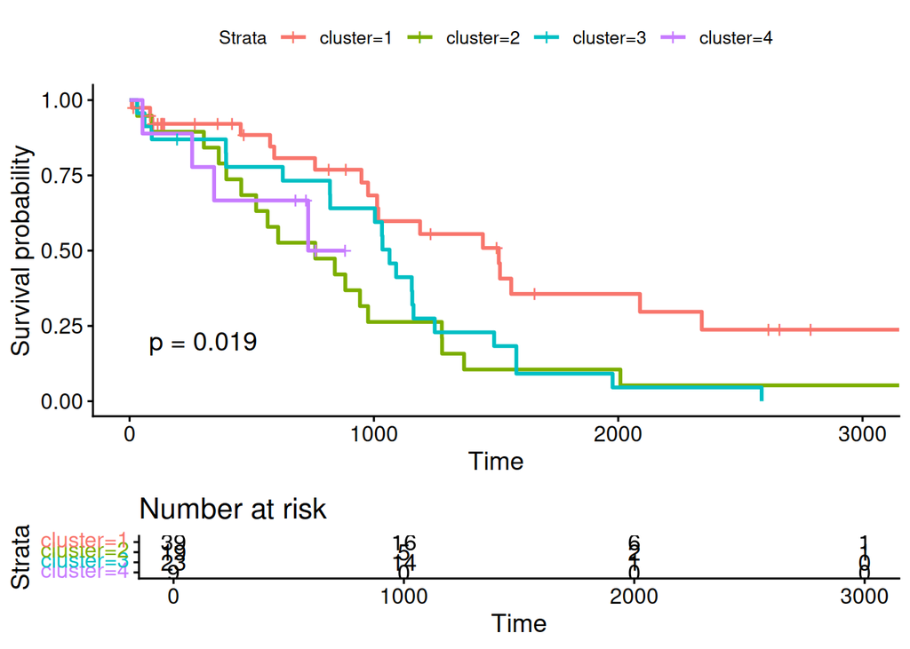

```r
set.seed(42)
fit <- survfit(Surv(time, vital_status) ~ cluster, data = df_combined)
(km_plot <- ggsurvplot(fit, data = df_combined, risk.table = TRUE, pval = TRUE, xlim = c(0,3000)))
```

```r
pairwise_survdiff(Surv(time, vital_status) ~ cluster, data = df_combined)
```

```
##
##  Pairwise comparisons using Log-Rank test
##
## data:  df_combined and cluster
##
##   1     2     3
## 2 0.024 -     -
## 3 0.055 0.655 -
## 4 0.274 0.838 0.574
##
## P value adjustment method: BH
```

# REMOVE THE OUTLIER

```r
Lcross_stroben_filtered <- Lcross_stroben[names(Lcross_stroben) != "TCGA-23-1121-01Z-00-DX1.E2F25441-32C3-46BF-A845-CB4FA787E8CB"]
```

```r
Lfun_stroben_filtered <- fsmooth(Lcross_stroben_filtered, centrata = T)
plot(Lfun_stroben_filtered$fd)
```

```
## [1] "done"
```

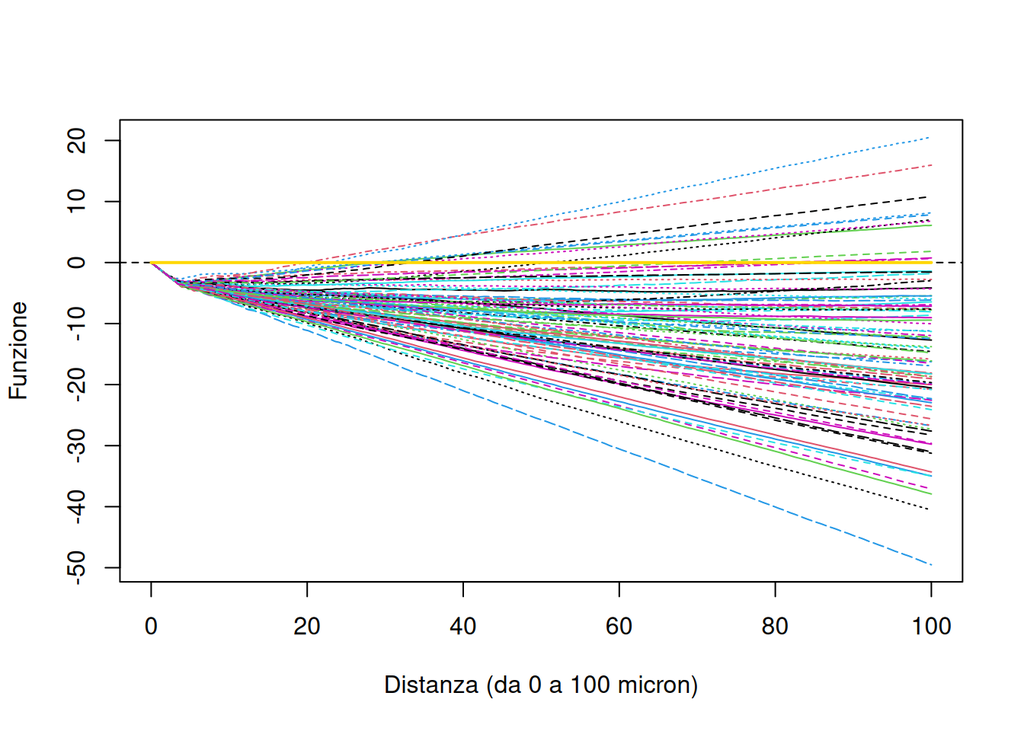

```r
lines(c(0,100), c(0,0), col = "gold", lwd = 2)
```

```r
fpca_filt <- pca.fd(Lfun_stroben_filtered$fd, nharm = 4, Lfun_stroben_filtered$fdPar)
rownames(fpca_filt$scores) <- names(Lcross_stroben_filtered) # "nome" dei pazienti (numero del paziente)

fpcaVarmx <- varmx.pca.fd(fpca_filt)


set.seed(123)
fpca_km_filt <- kmeans(fpca_filt$scores[,c(1,4)], 4)
fpca_hc_filt <- hclust(dist(fpca_filt$scores[,c(1,4)]), method = "ward.D2")
memb_filt <- cutree(fpca_hc_filt, k = 4)
```

```r
#ggdendrogram(dhc, rotate = TRUE, size = 2)
table(kmean = fpca_km_filt$cluster)
```

```
## kmean
##  1  2  3  4
## 33 31 12 14
```

```r
table(ward.d2 = memb_filt)
```

```
## ward.d2
##  1  2  3  4
## 31 27 16 16
```

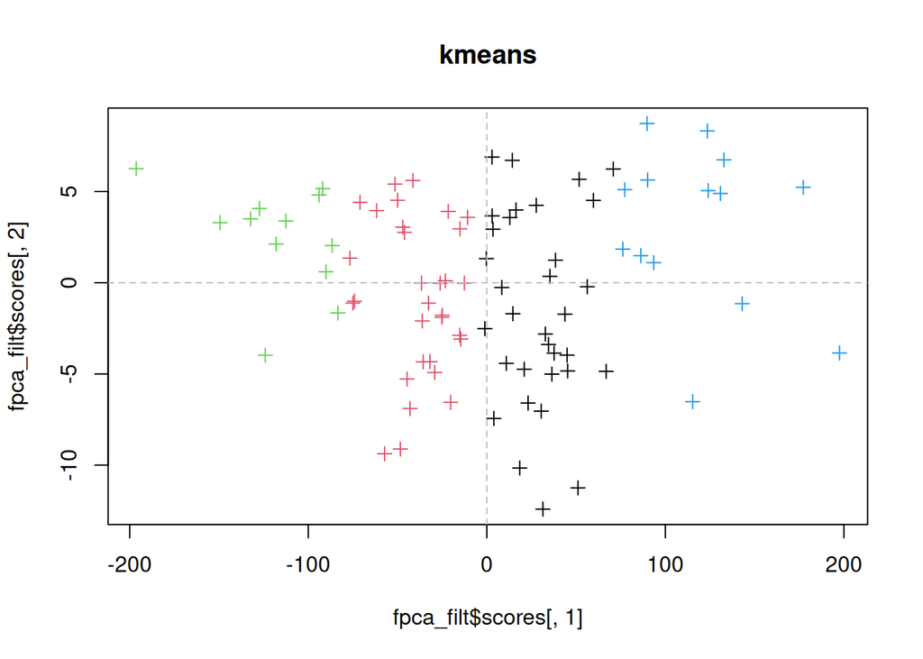

```r
plot(fpca_filt$scores[,1], fpca_filt$scores[,2], col = fpca_km_filt$cluster, pch = 3, main = "kmeans")
abline(v = 0, lty = "dashed", col = "grey")
abline(h = 0, lty = "dashed", col = "grey")
```

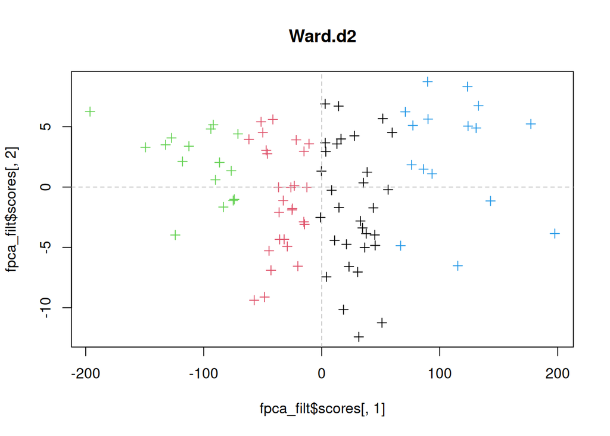

```r
plot(fpca_filt$scores[,1], fpca_filt$scores[,2], col = memb_filt, pch = 3, main = "Ward.d2")
abline(v = 0, lty = "dashed", col = "grey")
abline(h = 0, lty = "dashed", col = "grey")
```

```r
df_ilaria <- meta_ilaria |>
  dplyr::select(patientID, cluster)
# 3. Clean Dataset B to match IDs
# We extract the first 12 characters (e.g., "TCGA-25-1326")
df_clust_filt <- data.frame(
  patientID = substr(names(memb_filt), 1, 12),
  cluster_kmean = fpca_km_filt$cluster,
  cluster_ward = memb_filt
) |> print()
```

```
##                                                                 patientID
## TCGA-13-A5FU-01Z-00-DX1.9AD9E4B9-3F87-4879-BC0F-148B12C09036 TCGA-13-A5FU
## TCGA-23-1021-01Z-00-DX1.F07C221B-D401-47A5-9519-10DE59CA1E9D TCGA-23-1021
## TCGA-23-1022-01Z-00-DX1.AF9E523E-CB0F-4AB5-AD43-C96731BF9141 TCGA-23-1022
## TCGA-23-1023-01Z-00-DX1.0C96E118-A4D9-4A9A-B95E-C0AA114D2483 TCGA-23-1023
## TCGA-23-1024-01Z-00-DX1.B9194D3F-C6F4-4FC8-B0CA-6E347FF4F885 TCGA-23-1024
## TCGA-23-1026-01Z-00-DX1.2875B4F7-D6B2-4C72-8A68-4E7C92D04BF0 TCGA-23-1026
## TCGA-23-1027-01Z-00-DX1.53F9DFF4-6811-4184-B2FD-1F6706B948FD TCGA-23-1027
## TCGA-23-1028-01Z-00-DX1.117B4B7B-F796-4D33-A645-CD80E5C43E6D TCGA-23-1028
## TCGA-23-1029-01Z-00-DX1.0044B39A-51B3-4F76-90A9-00CDF851DE2A TCGA-23-1029
## TCGA-23-1030-01Z-00-DX1.FC93147F-FB55-4C62-B187-337A5C107096 TCGA-23-1030
## TCGA-23-1031-01Z-00-DX1.12B1996D-E5BB-424C-B59E-4BE7E1ED6BA1 TCGA-23-1031
## TCGA-23-1032-01Z-00-DX1.0C1074AE-D59C-4C74-B929-593AE89E5DC1 TCGA-23-1032
## TCGA-23-1107-01Z-00-DX1.5B9C1283-62B5-4329-873D-009FA939CA69 TCGA-23-1107
## TCGA-23-1109-01Z-00-DX1.FB0886B9-8108-4A74-8A29-FEA4381AD69C TCGA-23-1109
## TCGA-23-1110-01Z-00-DX1.61C2DBB8-7F5C-4878-BEDC-6AE061A2D7D4 TCGA-23-1110
## TCGA-23-1111-01Z-00-DX1.A99421E1-C73E-42AE-990F-E5E6D26EDDBE TCGA-23-1111
## TCGA-23-1113-01Z-00-DX1.D72B1587-444A-4DEC-8D92-703699822BE2 TCGA-23-1113
## TCGA-23-1114-01Z-00-DX1.26CCA42E-4947-4318-A983-D3B31603482E TCGA-23-1114
## TCGA-23-1116-01Z-00-DX1.FC5FC1E1-56DD-498C-AA9F-4434C6E733A8 TCGA-23-1116
## TCGA-23-1117-01Z-00-DX1.783914B6-B079-4828-B77B-4C6306FAE4C1 TCGA-23-1117
## TCGA-23-1118-01Z-00-DX1.D69E130E-33C7-4F8A-99AF-400B81378578 TCGA-23-1118
## TCGA-23-1119-01Z-00-DX1.44D3D70A-A421-4962-8385-2A3CF8E9880A TCGA-23-1119
## TCGA-23-1120-01Z-00-DX1.59367B12-17F1-41AA-A6FB-8D940365176A TCGA-23-1120
## TCGA-23-1122-01Z-00-DX1.991C230C-E3B4-4DAC-9DCC-69E9FA7DF772 TCGA-23-1122
## TCGA-23-1123-01Z-00-DX1.764A8E5C-F2E7-441D-B9FB-23ECF7183740 TCGA-23-1123
## TCGA-23-1809-01Z-00-DX1.A8767DEC-EB1A-4EDC-906E-C0560A30455F TCGA-23-1809
## TCGA-23-2072-01Z-00-DX1.478243FF-BFF0-48A4-ADEA-DE789331A50E TCGA-23-2072
## TCGA-23-2077-01Z-00-DX1.9EB664FA-CC13-4A49-89BA-8A4573CE48F1 TCGA-23-2077
## TCGA-23-2078-01Z-00-DX1.E31A9C1E-00EF-4B0D-A15D-6A5C2D00E986 TCGA-23-2078
## TCGA-23-2079-01Z-00-DX1.01383205-B7A7-4529-9207-880687650A50 TCGA-23-2079
## TCGA-23-2081-01Z-00-DX1.4105A382-4C2B-4C62-AC93-CB21CC360254 TCGA-23-2081
## TCGA-23-2084-01Z-00-DX1.94780F2B-9A88-47ED-982B-0048081309C9 TCGA-23-2084
## TCGA-23-2641-01Z-00-DX1.DB792236-39EC-4090-9938-B0915C3378A0 TCGA-23-2641
## TCGA-23-2643-01Z-00-DX1.E60DF03D-326E-4182-84DA-77263C4C52B3 TCGA-23-2643
## TCGA-23-2645-01Z-00-DX1.72C0AB89-9A64-4656-B03E-A5D65BA03188 TCGA-23-2645
## TCGA-23-2647-01Z-00-DX1.21E5D0D8-6BA8-4D49-BA70-EC228CF10387 TCGA-23-2647
## TCGA-23-2649-01Z-00-DX1.C94C3B32-D5F5-4A85-9F35-50B377FF9E75 TCGA-23-2649
## TCGA-25-1312-01Z-00-DX1.733EC7A7-0FC8-4DDC-B366-DF5A45D6BB4E TCGA-25-1312
## TCGA-25-1313-01Z-00-DX1.5A2732D5-01D6-4285-9283-1839E1703C27 TCGA-25-1313
```

[output cut: 218 more lines]

```
## TCGA-25-2401-01Z-00-DX1.AEA99982-DB6B-4178-BEDC-6E1F605B8D7C            2
## TCGA-25-2404-01Z-00-DX1.7193B185-31C3-41D0-9194-86DEDF15F096            2
## TCGA-25-2408-01Z-00-DX1.760F6B8D-A61E-4C87-B90D-82E1AF56C204            1
## TCGA-25-2409-01Z-00-DX1.34FFD6A9-4919-4DF5-8415-215CC833F12D            2
## TCGA-3P-A9WA-01Z-00-DX1.A5FDC436-7F0D-4DD2-8644-CEF1BFF9C614            2
## TCGA-42-2587-01Z-00-DX1.7a887a16-a8bc-403b-ab71-a8b43e5613fc            1
## TCGA-57-1582-01Z-00-DX1.BDF02DAA-E520-46BD-A479-58CAA4354B1A            1
## TCGA-57-1583-01Z-00-DX1.88ACB045-1DBD-4F0B-A6D0-53B6C208805C            1
## TCGA-57-1585-01Z-00-DX1.934E0F30-F804-4CFA-92D5-41576DA6C367            4
## TCGA-57-1586-01Z-00-DX1.5C85A9B1-9ACC-4D62-BA09-91F8BDB2A058            4
## TCGA-57-1992-01Z-00-DX1.1022B1ED-3DC1-4F71-8635-0F8B28138B8C            3
## TCGA-57-1993-01Z-00-DX1.464F641B-AA9F-49A7-A224-88D9847159DF            4
## TCGA-57-1994-01Z-00-DX1.A0798185-30C5-4C32-B1A8-B440D4F4ED95            4
## TCGA-5X-AA5U-01Z-00-DX1.1A03C105-4086-4AAB-B821-A9E8156FA704            2
## TCGA-WR-A838-01Z-00-DX1.5FE22DE4-CEFB-45F6-9299-505023A8F3BA            2
```

```r
# 4. Merge to find correspondence
comparison_stroben_filt <- inner_join(df_ilaria, df_clust_filt, by = "patientID") |>
  arrange(cluster_ward, patientID)

# 5. Display the Result
print(comparison_stroben_filt)
```

```
##       patientID cluster cluster_kmean cluster_ward
## 1  TCGA-13-A5FU       4             1            1
## 2  TCGA-23-1031       1             1            1
## 3  TCGA-23-1114       1             1            1
## 4  TCGA-23-1116       1             1            1
## 5  TCGA-23-1120       1             1            1
## 6  TCGA-23-1122       1             1            1
## 7  TCGA-23-2081       1             1            1
## 8  TCGA-23-2641       1             1            1
## 9  TCGA-23-2645       1             1            1
## 10 TCGA-23-2647       1             1            1
## 11 TCGA-25-1313       3             1            1
## 12 TCGA-25-1314       3             1            1
## 13 TCGA-25-1319       3             1            1
## 14 TCGA-25-1320       3             1            1
```

[output cut: 76 more lines]

```r
table("ilaria_clust" = comparison_stroben_filt$cluster, "valerio_clust" = comparison_stroben_filt$cluster_ward)
```

```
##             valerio_clust
## ilaria_clust  1  2  3  4
##            1 10 15 11  3
##            2  7  8  3  2
##            3 10  4  1  7
##            4  4  0  1  4
```

# Survival analysis

```r
ov_meta <- readRDS("~/repositories/spatialPointProcess_clustering/dataset/TCGA_data/survival_dataset_&_metadata.rds")
```

```r
df_combined_filt <- ov_meta |>
  # Select only the columns we want to add from the first df
  inner_join(df_clust_filt |> dplyr::select(patientID, cluster_kmean), by = "patientID")
```

```
## Ignoring unknown labels:
## • fill : "Strata"
## • linetype : "1"
```

[output not shown]

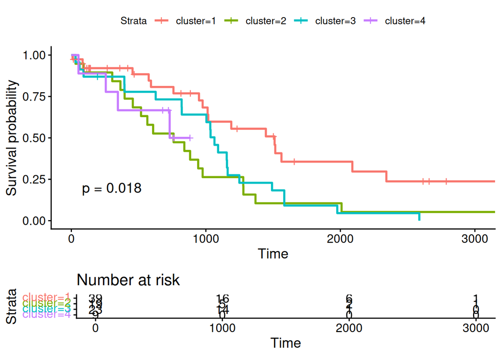

```r
set.seed(42)
fit_filt <- survfit(Surv(time, vital_status) ~ cluster, data = df_combined_filt)
(km_plot_filt <- ggsurvplot(fit, data = df_combined_filt, risk.table = TRUE, pval = TRUE, xlim = c(0,3000)))
```

```r
pairwise_survdiff(Surv(time, vital_status) ~ cluster, data = df_combined_filt)
```

```
##
##  Pairwise comparisons using Log-Rank test
##
## data:  df_combined_filt and cluster
##
##   1     2     3
## 2 0.024 -     -
## 3 0.052 0.670 -
## 4 0.274 0.838 0.599
##
## P value adjustment method: BH
```

# Sketching

```r
sketch_spatial_fast <- function(ppp_obj, idx, n_target) {
  if (length(idx) <= n_target) return(idx)

  # Corrected math: Number of bins per axis should be the square root
  # of the total desired boxes (n_target * 5)
  grid_res <- ceiling(sqrt(n_target * 5))

  # Get coordinates
  x_coords <- ppp_obj$x[idx]
  y_coords <- ppp_obj$y[idx]

  # Assign each point to an X and Y grid bin
  x_bin <- findInterval(x_coords, seq(min(x_coords), max(x_coords), length.out = grid_res))
  y_bin <- findInterval(y_coords, seq(min(y_coords), max(y_coords), length.out = grid_res))

  # Create a unique ID for each grid square
  grid_id <- paste(x_bin, y_bin, sep = "_")

  # Shuffle the data randomly
  shuffled_order <- sample(length(idx))
  idx_shuffled <- idx[shuffled_order]
  grid_id_shuffled <- grid_id[shuffled_order]

  # By taking the first occurrence of each grid_id, we get exactly 1 random cell per grid square!
  kept_idx <- idx_shuffled[!duplicated(grid_id_shuffled)]

  # If the grid gave us more points than n_target, randomly downsample to exactly n_target
  if (length(kept_idx) > n_target) {
    kept_idx <- sample(kept_idx, n_target)
  }

  return(kept_idx)
}
```

```r
# Pure R Spatial Sketching Function
sketch_spatial_R <- function(ppp_obj, idx, n_target) {
  if (length(idx) <= n_target) return(idx)

  # Extract X and Y coordinates for these specific points
  coords <- cbind(x = ppp_obj$x[idx], y = ppp_obj$y[idx])

  # Cluster the physical space into 'n_target' even regions
  # Using MacQueen algorithm because it is blazingly fast for 2D coordinates
  km <- kmeans(coords, centers = n_target, algorithm = "MacQueen", iter.max = 15)

  # Pick one random cell from each spatial cluster
  # This forces the downsampled cells to perfectly trace the tissue structure
  sketched_rel_idx <- tapply(seq_along(idx), km$cluster, function(x) sample(x, 1))

  return(idx[sketched_rel_idx])
}
```

```r
Lcross_personal <- function(ppp_obj, mark_i, mark_j, mark_column, downsample = TRUE, downsample_method = c("sketch_R", "sketch_fast", "standard"), n_down = 10000, ...) {

  # Ensure a valid method is selected (defaults to "sketch_R" if none is specified)
  downsample_method <- match.arg(downsample_method)

  # 0. If marks are a dataframe, extract the specific column we want to use
  if (is.data.frame(marks(ppp_obj))) {
    marks(ppp_obj) <- marks(ppp_obj)[[mark_column]]
  }

  # 1. Get the indices of the specific cell types dynamically
  idx_i <- which(marks(ppp_obj) == mark_i)
  idx_j <- which(marks(ppp_obj) == mark_j)

  if(length(idx_i) < 2 | length(idx_j) < 2) {
    warning(paste("Not enough points for", mark_i, "and/or", mark_j, "to compute Lcross. Returning NULL."))
    return(NULL)
  }

  # 2. Handle Downsampling
  if (downsample) {
    if (downsample_method == "sketch_R") {
      # MacQueen k-means sketching
      keep_i <- sketch_spatial_R(ppp_obj, idx_i, n_down)
      keep_j <- sketch_spatial_R(ppp_obj, idx_j, n_down)

    } else if (downsample_method == "sketch_fast") {
      # Fast grid-based sketching (requires ppp_obj to be passed)
      keep_i <- sketch_spatial_fast(ppp_obj, idx_i, n_down)
      keep_j <- sketch_spatial_fast(ppp_obj, idx_j, n_down)

    } else if (downsample_method == "standard") {
      # Standard random downsampling
      keep_i <- sample(idx_i, min(length(idx_i), n_down))
      keep_j <- sample(idx_j, min(length(idx_j), n_down))
    }

    # Subset the ppp object
    ppp_sub <- ppp_obj[c(keep_i, keep_j)]

  } else {
    ppp_sub <- ppp_obj[c(idx_i, idx_j)]
  }

  # 3. Calculate Lcross
  L <- Lcross(ppp_sub, i = mark_i, j = mark_j, ...)

  return(L)
}
```

```r
Lcross_sketch <- map(ppp_list, \(ppp_obj) {
  Lcross_personal(ppp_obj,
                  mark_i = "neoplastic",
                  mark_j = "stromal_benign",
                  mark_column = "merged_type",
                  downsample = TRUE,
                  downsample_method = "sketch_fast",
                  n_down = 10000, rmax = 100,
                  correction = "border", r = r_values)
})
```

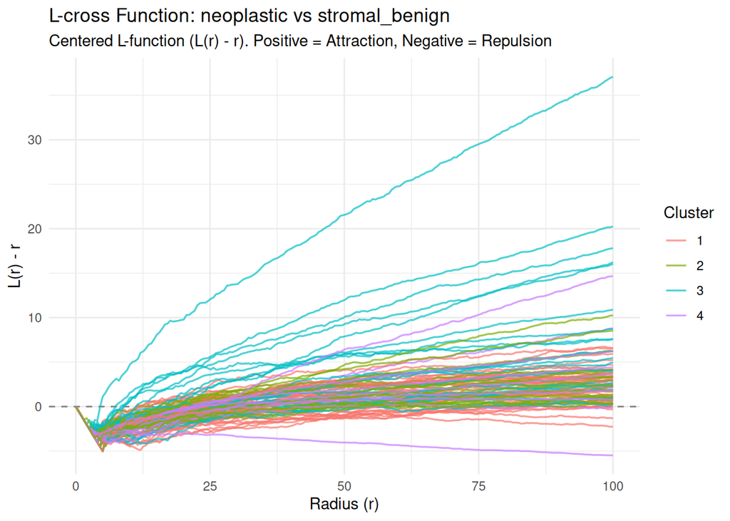

```r
plot_colored <- plot_fv_list(
  list_of_funcs = Lcross_sketch,
  comparison_df = meta_ilaria,
  correction = "border"
)

plot_colored
```

### Remove the outliner

```r
Lcross_sketch <- Lcross_sketch[names(Lcross_sketch) != "TCGA-23-1121-01Z-00-DX1.E2F25441-32C3-46BF-A845-CB4FA787E8CB"]
```

```r
Lfun_sketch <- fsmooth(Lcross_sketch, centrata = T)
```

```r
plot(Lfun_sketch$fd)
```

```
## [1] "done"
```

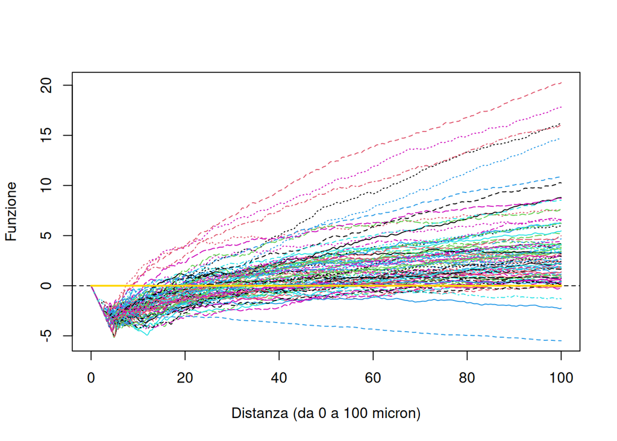

```r
lines(c(0,100), c(0,0), col = "gold", lwd = 2)
```

```r
fpca_sk <- pca.fd(Lfun_sketch$fd, nharm = 4, Lfun_sketch$fdPar)
rownames(fpca_sk$scores) <- names(Lcross_sketch) # "nome" dei pazienti (numero del paziente)

set.seed(123)
fpca_km_sk <- kmeans(fpca_sk$scores[,c(1,4)], 4)
fpca_hc_sk <- hclust(dist(fpca_sk$scores[,c(1,4)]), method = "ward.D2")
memb_sk <- cutree(fpca_hc_sk, k = 4)

table(kmean = fpca_km_sk$cluster)
```

```
## kmean
##  1  2  3  4
##  5 29 15 41
```

```r
table(ward.d2 = memb_sk)
```

```
## ward.d2
##  1  2  3  4
##  7 51 26  6
```

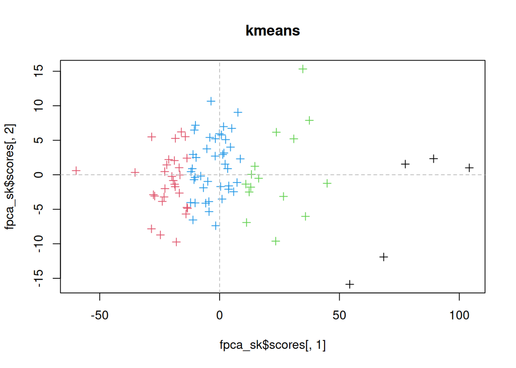

```r
plot(fpca_sk$scores[,1], fpca_sk$scores[,2], col = fpca_km_sk$cluster, pch = 3, main = "kmeans")
abline(v = 0, lty = "dashed", col = "grey")
abline(h = 0, lty = "dashed", col = "grey")
```

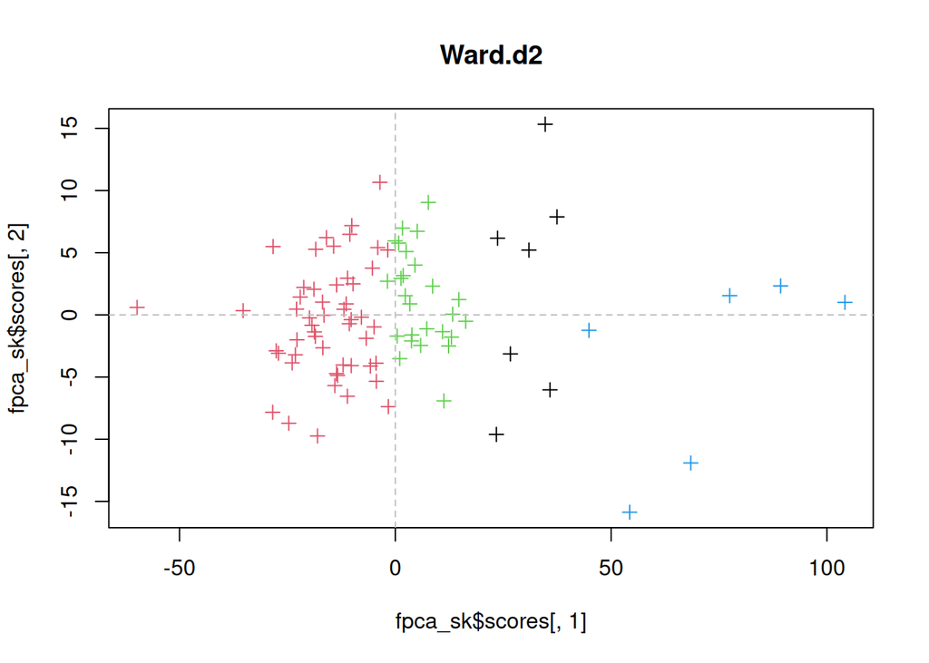

```r
plot(fpca_sk$scores[,1], fpca_sk$scores[,2], col = memb_sk, pch = 3, main = "Ward.d2")
abline(v = 0, lty = "dashed", col = "grey")
abline(h = 0, lty = "dashed", col = "grey")
```

```r
df_ilaria <- meta_ilaria |>
  dplyr::select(patientID, cluster)
# 3. Clean Dataset B to match IDs
# We extract the first 12 characters (e.g., "TCGA-25-1326")
df_clust_sketch <- data.frame(
  patientID = substr(names(memb_sk), 1, 12),
  cluster_kmean = fpca_km_sk$cluster,
  cluster_ward = memb_sk
) |> print()
```

```
##                                                                 patientID
## TCGA-13-A5FU-01Z-00-DX1.9AD9E4B9-3F87-4879-BC0F-148B12C09036 TCGA-13-A5FU
## TCGA-23-1021-01Z-00-DX1.F07C221B-D401-47A5-9519-10DE59CA1E9D TCGA-23-1021
## TCGA-23-1022-01Z-00-DX1.AF9E523E-CB0F-4AB5-AD43-C96731BF9141 TCGA-23-1022
## TCGA-23-1023-01Z-00-DX1.0C96E118-A4D9-4A9A-B95E-C0AA114D2483 TCGA-23-1023
## TCGA-23-1024-01Z-00-DX1.B9194D3F-C6F4-4FC8-B0CA-6E347FF4F885 TCGA-23-1024
## TCGA-23-1026-01Z-00-DX1.2875B4F7-D6B2-4C72-8A68-4E7C92D04BF0 TCGA-23-1026
## TCGA-23-1027-01Z-00-DX1.53F9DFF4-6811-4184-B2FD-1F6706B948FD TCGA-23-1027
## TCGA-23-1028-01Z-00-DX1.117B4B7B-F796-4D33-A645-CD80E5C43E6D TCGA-23-1028
## TCGA-23-1029-01Z-00-DX1.0044B39A-51B3-4F76-90A9-00CDF851DE2A TCGA-23-1029
## TCGA-23-1030-01Z-00-DX1.FC93147F-FB55-4C62-B187-337A5C107096 TCGA-23-1030
## TCGA-23-1031-01Z-00-DX1.12B1996D-E5BB-424C-B59E-4BE7E1ED6BA1 TCGA-23-1031
## TCGA-23-1032-01Z-00-DX1.0C1074AE-D59C-4C74-B929-593AE89E5DC1 TCGA-23-1032
## TCGA-23-1107-01Z-00-DX1.5B9C1283-62B5-4329-873D-009FA939CA69 TCGA-23-1107
## TCGA-23-1109-01Z-00-DX1.FB0886B9-8108-4A74-8A29-FEA4381AD69C TCGA-23-1109
## TCGA-23-1110-01Z-00-DX1.61C2DBB8-7F5C-4878-BEDC-6AE061A2D7D4 TCGA-23-1110
## TCGA-23-1111-01Z-00-DX1.A99421E1-C73E-42AE-990F-E5E6D26EDDBE TCGA-23-1111
## TCGA-23-1113-01Z-00-DX1.D72B1587-444A-4DEC-8D92-703699822BE2 TCGA-23-1113
## TCGA-23-1114-01Z-00-DX1.26CCA42E-4947-4318-A983-D3B31603482E TCGA-23-1114
## TCGA-23-1116-01Z-00-DX1.FC5FC1E1-56DD-498C-AA9F-4434C6E733A8 TCGA-23-1116
## TCGA-23-1117-01Z-00-DX1.783914B6-B079-4828-B77B-4C6306FAE4C1 TCGA-23-1117
## TCGA-23-1118-01Z-00-DX1.D69E130E-33C7-4F8A-99AF-400B81378578 TCGA-23-1118
## TCGA-23-1119-01Z-00-DX1.44D3D70A-A421-4962-8385-2A3CF8E9880A TCGA-23-1119
## TCGA-23-1120-01Z-00-DX1.59367B12-17F1-41AA-A6FB-8D940365176A TCGA-23-1120
## TCGA-23-1122-01Z-00-DX1.991C230C-E3B4-4DAC-9DCC-69E9FA7DF772 TCGA-23-1122
## TCGA-23-1123-01Z-00-DX1.764A8E5C-F2E7-441D-B9FB-23ECF7183740 TCGA-23-1123
## TCGA-23-1809-01Z-00-DX1.A8767DEC-EB1A-4EDC-906E-C0560A30455F TCGA-23-1809
## TCGA-23-2072-01Z-00-DX1.478243FF-BFF0-48A4-ADEA-DE789331A50E TCGA-23-2072
## TCGA-23-2077-01Z-00-DX1.9EB664FA-CC13-4A49-89BA-8A4573CE48F1 TCGA-23-2077
## TCGA-23-2078-01Z-00-DX1.E31A9C1E-00EF-4B0D-A15D-6A5C2D00E986 TCGA-23-2078
## TCGA-23-2079-01Z-00-DX1.01383205-B7A7-4529-9207-880687650A50 TCGA-23-2079
## TCGA-23-2081-01Z-00-DX1.4105A382-4C2B-4C62-AC93-CB21CC360254 TCGA-23-2081
## TCGA-23-2084-01Z-00-DX1.94780F2B-9A88-47ED-982B-0048081309C9 TCGA-23-2084
## TCGA-23-2641-01Z-00-DX1.DB792236-39EC-4090-9938-B0915C3378A0 TCGA-23-2641
## TCGA-23-2643-01Z-00-DX1.E60DF03D-326E-4182-84DA-77263C4C52B3 TCGA-23-2643
## TCGA-23-2645-01Z-00-DX1.72C0AB89-9A64-4656-B03E-A5D65BA03188 TCGA-23-2645
## TCGA-23-2647-01Z-00-DX1.21E5D0D8-6BA8-4D49-BA70-EC228CF10387 TCGA-23-2647
## TCGA-23-2649-01Z-00-DX1.C94C3B32-D5F5-4A85-9F35-50B377FF9E75 TCGA-23-2649
## TCGA-25-1312-01Z-00-DX1.733EC7A7-0FC8-4DDC-B366-DF5A45D6BB4E TCGA-25-1312
## TCGA-25-1313-01Z-00-DX1.5A2732D5-01D6-4285-9283-1839E1703C27 TCGA-25-1313
```

[output cut: 218 more lines]

```
## TCGA-25-2401-01Z-00-DX1.AEA99982-DB6B-4178-BEDC-6E1F605B8D7C            2
## TCGA-25-2404-01Z-00-DX1.7193B185-31C3-41D0-9194-86DEDF15F096            1
## TCGA-25-2408-01Z-00-DX1.760F6B8D-A61E-4C87-B90D-82E1AF56C204            2
## TCGA-25-2409-01Z-00-DX1.34FFD6A9-4919-4DF5-8415-215CC833F12D            2
## TCGA-3P-A9WA-01Z-00-DX1.A5FDC436-7F0D-4DD2-8644-CEF1BFF9C614            3
## TCGA-42-2587-01Z-00-DX1.7a887a16-a8bc-403b-ab71-a8b43e5613fc            2
## TCGA-57-1582-01Z-00-DX1.BDF02DAA-E520-46BD-A479-58CAA4354B1A            2
## TCGA-57-1583-01Z-00-DX1.88ACB045-1DBD-4F0B-A6D0-53B6C208805C            2
## TCGA-57-1585-01Z-00-DX1.934E0F30-F804-4CFA-92D5-41576DA6C367            3
## TCGA-57-1586-01Z-00-DX1.5C85A9B1-9ACC-4D62-BA09-91F8BDB2A058            2
## TCGA-57-1992-01Z-00-DX1.1022B1ED-3DC1-4F71-8635-0F8B28138B8C            2
## TCGA-57-1993-01Z-00-DX1.464F641B-AA9F-49A7-A224-88D9847159DF            3
## TCGA-57-1994-01Z-00-DX1.A0798185-30C5-4C32-B1A8-B440D4F4ED95            4
## TCGA-5X-AA5U-01Z-00-DX1.1A03C105-4086-4AAB-B821-A9E8156FA704            2
## TCGA-WR-A838-01Z-00-DX1.5FE22DE4-CEFB-45F6-9299-505023A8F3BA            2
```

```r
# 4. Merge to find correspondence
comparison_sketch <- inner_join(df_ilaria, df_clust_sketch, by = "patientID") |>
  arrange(cluster_ward, patientID)

# 5. Display the Result
print(comparison_stroben)
```

```
##       patientID cluster cluster_kmean cluster_ward
## 1  TCGA-13-A5FU       4             2            1
## 2  TCGA-23-1021       1             3            1
## 3  TCGA-23-1028       1             3            1
## 4  TCGA-23-1029       1             3            1
## 5  TCGA-23-1031       1             3            1
## 6  TCGA-23-1110       1             3            1
## 7  TCGA-23-1114       1             2            1
## 8  TCGA-23-1116       1             3            1
## 9  TCGA-23-1117       1             3            1
## 10 TCGA-23-1119       1             3            1
## 11 TCGA-23-1120       1             3            1
## 12 TCGA-23-1122       1             3            1
## 13 TCGA-23-1809       1             3            1
## 14 TCGA-23-2072       1             3            1
```

[output cut: 77 more lines]

```r
table("ilaria_clust" = comparison_sketch$cluster, "valerio_ward" = comparison_sketch$cluster_ward)
```

```
##             valerio_ward
## ilaria_clust  1  2  3  4
##            1  1 24 14  0
##            2  2 13  5  0
##            3  3  9  5  5
##            4  1  5  2  1
```

```r
table("ilaria_clust" = comparison_sketch$cluster, "valerio_kmean" = comparison_sketch$cluster_kmean)
```

```
##             valerio_kmean
## ilaria_clust  1  2  3  4
##            1  0 14  3 22
##            2  0  7  3 10
##            3  4  5  7  6
##            4  1  3  2  3
```

## Survival analysis

```r
ov_meta <- readRDS("~/repositories/spatialPointProcess_clustering/dataset/TCGA_data/survival_dataset_&_metadata.rds")
```

```r
df_combined_sketch <- ov_meta |>
  # Select only the columns we want to add from the first df
  inner_join(df_clust_sketch |> dplyr::select(patientID, cluster_kmean), by = "patientID")
```

```
## Ignoring unknown labels:
## • fill : "Strata"
## • linetype : "1"
```

[output not shown]

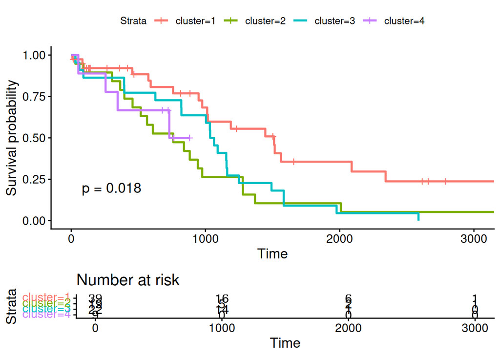

```r
set.seed(42)
fit <- survfit(Surv(time, vital_status) ~ cluster, data = df_combined_sketch)
(km_plot <- ggsurvplot(fit, data = df_combined_sketch, risk.table = TRUE, pval = TRUE, xlim = c(0,3000)))
```

```r
pairwise_survdiff(Surv(time, vital_status) ~ cluster, data = df_combined_sketch)
```

```
##
##  Pairwise comparisons using Log-Rank test
##
## data:  df_combined_sketch and cluster
##
##   1     2     3
## 2 0.024 -     -
## 3 0.052 0.670 -
## 4 0.274 0.838 0.599
##
## P value adjustment method: BH
```

COSE DA FARE:

dopo aver rimosso casi strani, prendo tutti i pazienti e faccio tutta la pipe con i gruppi di clustering faccio survival.

sketching: subsampling 50k cells, ribilianciare i punti con pesi

unisco benign e stromal match i neoplastic con le altre.